# Baseline Remittance and Proportion of employed members in Household

Nandini Das

2022-06-15

```r
load("~/Desktop/2022-DSPG-LivDiv-/data/livdivdata.RData")
view(livdiv)
baseline <- livdiv %>%
slice(1:306,)
```

# Relationship between Remittance, total mean income and mean expenditure in Baseline week by village

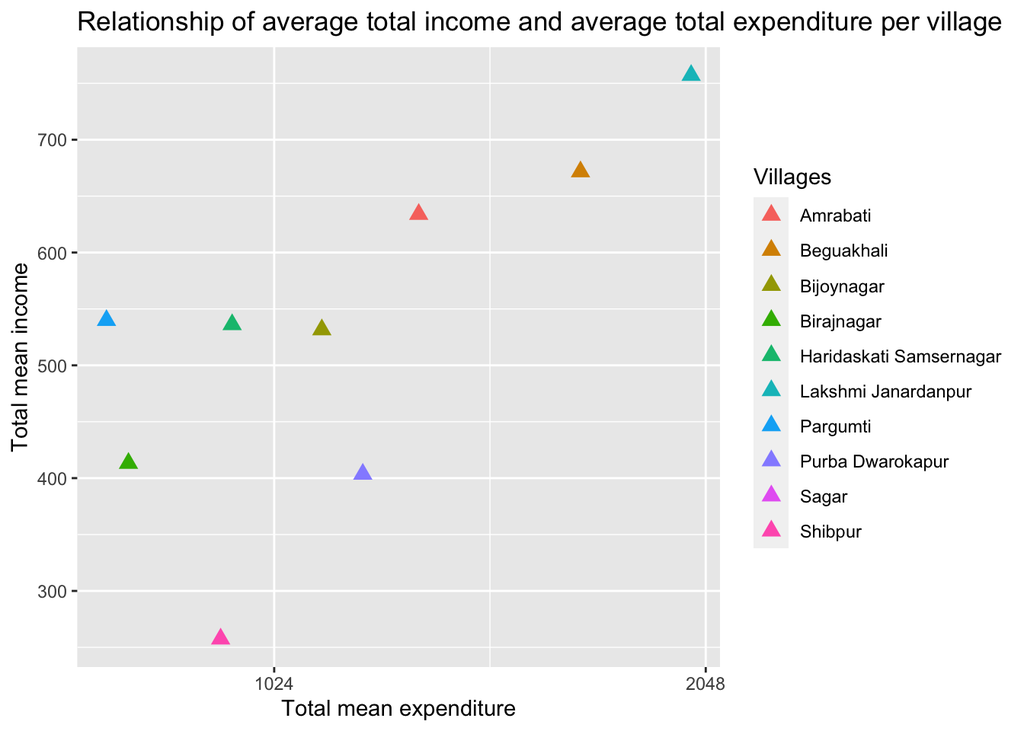

```r
baseline %>% select(village, exp_total, inc_total) %>% group_by(village) %>%summarise_all(mean) -> baseline.summary

figure_inc_spending <- ggplot(baseline.summary, aes(exp_total, inc_total, color= village))+geom_point(data=baseline.summary, shape=17, size=3) +labs(x="Total mean expenditure", y="Total mean income", color="Villages") + ggtitle("Relationship of average total income and average total expenditure per village")

figure_inc_spending + scale_x_continuous(trans='log2')
```

### Observations

As expected, there is an overall positive relationship between the total mean income and expenditure. Shibpur seems to have the lowest income. Lakshmi Janardanpur has the both highest income and expenditure. Pargumti is also an interesting case in hand since the households in this village seems to be earning a lot but has the lowest mean expenditure. On the other hand, Purba Dwarokapur spends more than 5 other villages on an average but earns the second lowest.

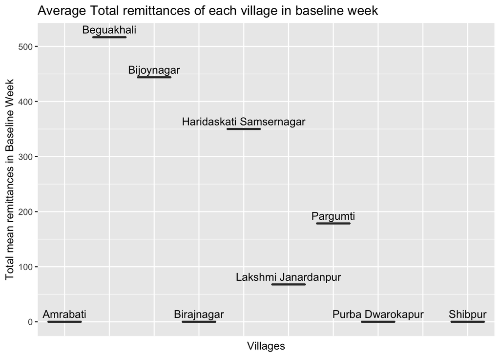

```r
baseline_rmt <- baseline %>% select(village, rmt_total)

baseline %>% select(village, head_age, head_edu, village, exp_total, hh_employed_prop,  rmt_total) %>% group_by(village) %>% summarise_all(mean) -> baseline.summary


ggplot(baseline.summary, aes(x=village, y=rmt_total)) + geom_boxplot() +labs(y="Total mean remittances in Baseline Week", x="Villages")+scale_x_discrete(guide = guide_axis(n.dodge=3))+ggtitle("Average Total remittances of each village in baseline week") +
  geom_text(
    aes(label = village, village = village),
    position = position_dodge(0.9),
    vjust = -0.5
  ) +
  theme(axis.ticks.x =element_blank(),
        axis.text.x = element_blank())
```

### Observations

This diagram shows that:

- Beguakhali has the highest remittance income and also has the second highest mean income and expenditure - not a surprising result.
- Shibpur, the lowest income village also has no remittance income.
- Lakshmi Janardanpur highest income and expenditure is probably not due to its high remittance.
- Pargumti earns a reasonable remittance yet their expenditure is low.
- Purba Dwarokapur earning source is not clear - remittance is 0 and it spends a lot more as compared to other villages. Land ownership?

# Average Household Employment Proportion By Village

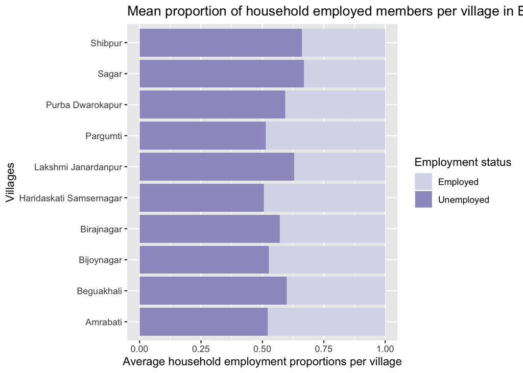

```r
df2 <- data.frame(s=rep(c("Employed", "Unemployed"), each=10),
                d=c("Amrabati","Beguakhali","Bijoynagar","Birajnagar","Haridaskati Samsernagar","Lakshmi Janardanpur","Pargumti","Purba Dwarokapur","Sagar","Shibpur"),
                l=c(0.4780612, 0.4007672, 0.4729048, 0.4285714,0.4944841, 0.3699830, 0.4861111, 0.4072666, 0.3307398, 0.3389172, 0.5219388, 0.5992328, 0.5270952, 0.5714286, 0.5055159, 0.6300170, 0.5138889, 0.5927334, 0.6692602, 0.6610828))

ggplot(data=df2, aes(x=d, y=l, fill=s,  width=0.9)) +
  geom_bar(stat="identity") +
  scale_fill_manual(values = c("#DADAEB", "#9E9AC8", "#6A51A3")) + labs(y="Average household employment proportions per village", x="Villages", fill="Employment status")+ggtitle("Mean proportion of household employed members per village in Baseline week") +coord_flip()
```